# GHRtools

A suite of R packages for climate and health workflows created by the Global Health Resilience (GHR) group at the Barcelona Supercomputing Center.

[figure not shown]

## From health and climate data to disease forecasts

**GHRtools** is a suite of R packages that support **climate and health workflows** by streamlining health and climate data collection and harmonization, exploratory analysis, Bayesian modelling and forecasting.

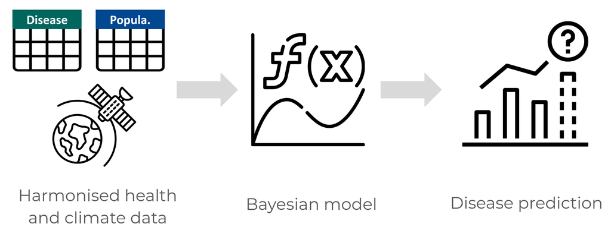

## Our tools

[figure not shown]

**data4health**

- Access, preprocess and aggregate health data at customized spatiotemporal resolutions.
- Use a set of functions to streamline health data pipelines or leverage a user-friendly graphical interface provided as a Shiny app within the package.

**clim4health**

- Obtain, transform and export climate data including reanalyses, forecasts, hindcasts, and weather stations.
- Apply common transformations of climate data including postprocessing, downscaling, spatiotemporal aggregations, and construct threshold-based vector suitability indicators.

[figure not shown]

**GHRexplore**

- Perform exploratory analysis of temporal and spatiotemporal health data including case counts, incidence rates, and covariates.
- Produce high-quality time series, heatmaps, seasonality, bivariate and correlation plots, as well as choropleth maps, with many customization options.

**GHRmodel**

- A modular and flexible approach to modeling health outcomes using INLA.
- It addresses common challenges when fitting INLA models, including covariate transformations, formula definitions with complex covariate effects, model fitting, diagnostic plots and model statistics.

[figure not shown]

**GHRpredict**

- Generate predictions of models fitted with GHRmodel.
- Evaluate the quality of your predictions using out-of-sample statistics, graphical diagnostics and outbreak detection capabilities using cross-validation